# alexwork

Alex Dombowsky

3/2/2021

# data

```r
load("cardiomort.RData")
```

# subsetting into overall and categories

```r
# cardio data
cardio_ov <- cardio[cardio$`Procedure Type` == "Overall", ]
cardio_cat <- cardio[cardio$`Procedure Type` != "Overall", ]
colnames(cardio_ov) <- c("id", "hospital", "type", "deaths", "procedures", "EMR")
cardio_ov <- cardio_ov[ , -3]

colnames(cardio_cat) <- c("id", "name", "category", "deaths", "procedures", "EMR")
cardio_cat$category <- as.factor(cardio_cat$category)
cardio_cat$category <- recode(cardio_cat$category,
       "STAT Mortality Category 1" = 1,
       "STAT Mortality Category 2" = 2,
       "STAT Mortality Category 3" = 3,
       "STAT Mortality Category 4" = 4,
       "STAT Mortality Category 5" = 5)
cardio_cat$category <- as.factor(cardio_cat$category)

# hospital covariates
hosp <- read.csv("hosp.csv")
hosp_full <- read.csv("hosp_full.csv")
```

# Basic Facts

```r
length(levels(as.factor(cardio$`Hospital Name`)))
```

```
## [1] 82
```

There are 82 hospitals, scattered seemingly across the US.

# Contingency Tables

```r
procedures <- aggregate(cardio_cat$procedures, by = list(Category = cardio_cat$category), FUN = sum)
colnames(procedures) <- c("Category", "Procedures")
procedures
```

```
##   Category Procedures
## 1        1      22607
## 2        2      24576
## 3        3       8711
## 4        4      16492
## 5        5       3220
```

In the whole data, we see that the ranking of number of procedures for each category is 2, 1, 4, 3, 5.

```r
deaths <- aggregate(cardio_cat$deaths, by = list(Category = cardio_cat$category), FUN = sum)
colnames(deaths) <- c("Category", "Deaths")
deaths
```

```
##   Category Deaths
## 1        1     77
## 2        2    350
## 3        3    194
## 4        4   1008
## 5        5    435
```

In the whole data, we see that the ranking of number of deaths for each category is 4, 5, 2, 3, 1.

# Summary Statistics of Volume

```r
quantile(cardio_ov$procedures, c(0.025, 0.5, 0.975))
```

```
##   2.5%    50%  97.5%
##  116.8  761.0 2631.8
```

The median number of procedures is 761.

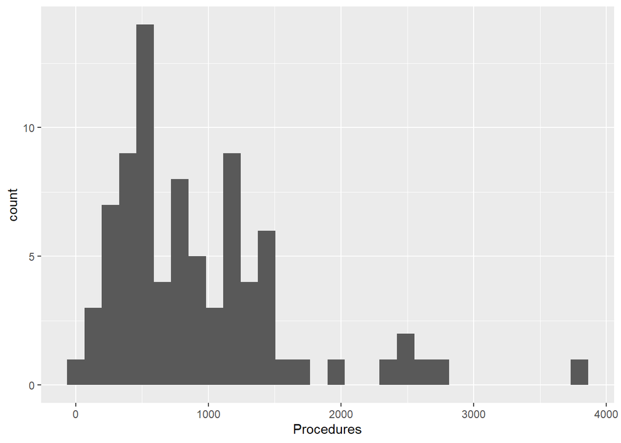

```r
ggplot(data.frame("Procedures" = cardio_ov$procedures), aes(x = Procedures)) + geom_histogram()
```

# Summary Statistics of Death

```r
quantile(cardio_ov$deaths, c(0.025, 0.5, 0.975))
```

```
##  2.5%   50% 97.5%
##   1.0  20.5  84.7
```

The median number of deaths is 20.

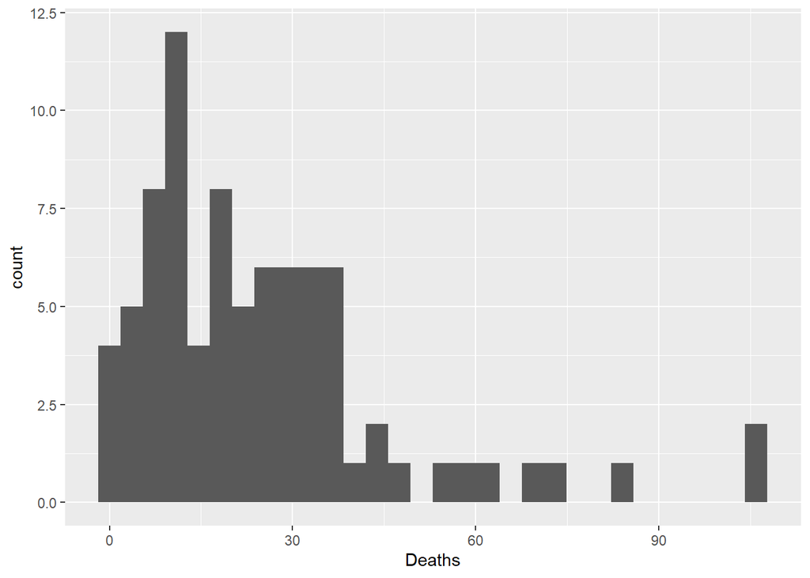

```r
ggplot(data.frame("Deaths" = cardio_ov$deaths), aes(x = Deaths)) + geom_histogram()
```

# Summary Statistics of Volume and Deaths

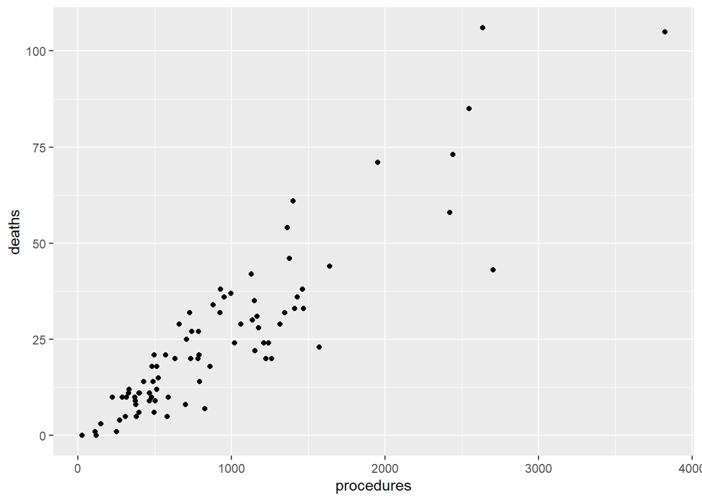

```r
ggplot(data = cardio_ov, aes(x = procedures, y = deaths)) + geom_point()
```

In the aggregated data, it does seem that the total number of procedures is positively correlated with the number of deaths (makes sense).

Let’s replicate the same graph from the paper.

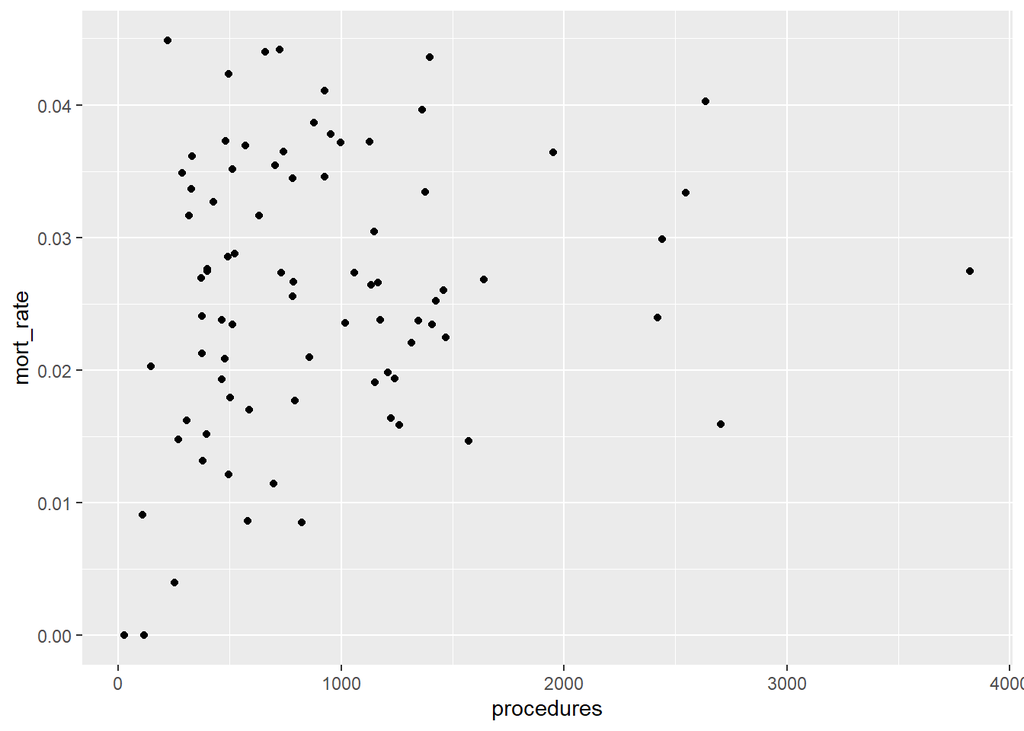

```r
cardio_ov$mort_rate <- cardio_ov$deaths/cardio_ov$procedures

ggplot(data = cardio_ov, aes(x = procedures, y = mort_rate)) + geom_point()
```

Similar to the paper, the variation in $\mathcal{O}_h$ is highest at hospitals with fewer total procedures. However, we don’t quite see the same dramatic decrease they have in the paper (probably because we’re focusing on different conditions).